# Duration of Use Besed on Gender, User type And Age

## by Abdullah Aljamhour

## Investigation Overview

> In this investigation I want to take a look of the relationship between duration of use aganist the other varibles (Gender, user type and age)

## Dataset Overview

> The data is information about a bike renting app, this data provides infomation like the age of the user, duration of the use, gender of the user.

#### In this slide you see the time that the bikes are used, from the plot you can see that most people use the bike around 8.3 minutes

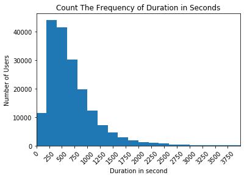

```python
binsize = 200 #set bin size for the plot
ticks = np.arange(0,4000,250) # using ticks to make the x easy to read
bins = np.arange(0, df.duration_sec.max()+binsize, binsize)
plt.hist(df.duration_sec, bins = bins);
plt.xlim(0,4000)
plt.xticks(ticks,rotation = 45);
plt.xlabel('Duration in second')
plt.ylabel('Number of Users')
plt.title('Count The Frequency of Duration in Seconds');
```

#### In the plot you can see the ratio of users type. most of the users are subscribers

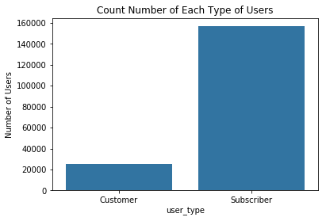

```python
base_color = sb.color_palette()[0] # set a fix color for all plots
sb.countplot(data = df, x = 'user_type', color = base_color);
plt.ylabel('Number of Users')
plt.title('Count Number of Each Type of Users');
```

#### In this plot you can see the number of each gender of the users

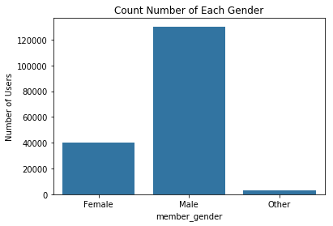

```python
sb.countplot(data = df, x = 'member_gender', color = base_color);
plt.ylabel('Number of Users')
plt.title('Count Number of Each Gender');
```

#### This plot shows us most of the users fall between 1987 - 1997 with a spike in the year 1980.

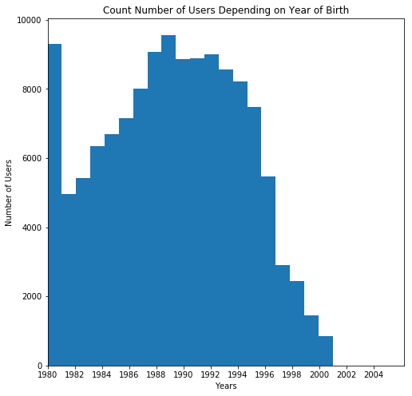

```python
maxsize= 2000
ticks = np.arange(1980,maxsize+5,2)
plt.figure(figsize=(8,8))
plt.hist(data= df , x='member_birth_year',bins = 100);
plt.xticks(ticks);
plt.xlim(1980,None);
plt.ylabel('Number of Users')
plt.xlabel('Years')
plt.title('Count Number of Users Depending on Year of Birth');
```

#### We can see that most of the are subsribers, but they use the service less duration than customer (non-subsribers)

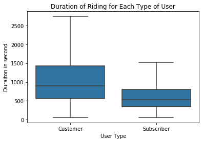

```python
sb.boxplot(data=df,y='duration_sec',x='user_type',showfliers=False,color = base_color); # using the box plot to plot the duration for each user type
plt.title('Duration of Riding for Each Type of User')
plt.xlabel('User Type')
plt.ylabel('Duraiton in second');
```

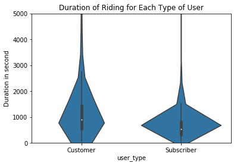

```python
sb.violinplot(data=df,y='duration_sec',x='user_type',color = base_color); # using the violin plot to plot the duration for each user type
plt.ylim(0,5000)
plt.title('Duration of Riding for Each Type of User')
plt.ylabel('Duration in second');
```

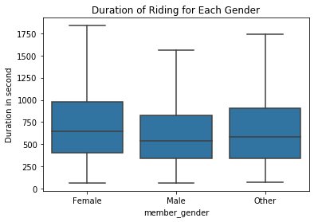

```python
sb.boxplot(data=df,y='duration_sec',x=df.member_gender,showfliers=False,color = base_color); # using the box plot to plot the duration for each gender
plt.ylabel('Duration in second')
plt.title('Duration of Riding for Each Gender');
```

#### Now yon see the relationship between 3 varibles (duration , type of use , gender),

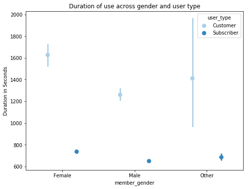

```python
fig = plt.figure(figsize = [8,6]) # using point plot to vizalise the 3 varibles (duration , type of use , gender) relationship
ax = sb.pointplot(data = df, y = 'duration_sec', x = 'member_gender', hue = 'user_type',
           palette = 'Blues', linestyles = '', dodge = 0.4)
plt.title('1-carat diamond prices across cut and clarity')
plt.title('Duration of use across gender and user type')
plt.ylabel('Duration in Seconds')
plt.show();
```